# Hierarchical model for sampling

```r
library(sampinfo)
library(bayesplot)
library(rstan)
library(knitr)
```

## Prepare your data:

To begin with, we have a dataset with many participants, each finishing a same set of questions. Within each question, there are several time points, where participants sample from a set of C options.  
In this toy dataset, total question number $Q = 5$. The question ID for each sampling time point is stored in qID.

```r
subset(sampinfo::raw_data,sID==1)
```

```
#>    qID sID final_choice tNo cID rating terminate
#> 1    1   1            1   1   5      3         1
#> 2    2   1            1   1   4      0         0
#> 3    2   1            1   2   3     -1         0
#> 4    2   1            1   3   6      3         1
#> 5    3   1            1   1   6      3         0
#> 6    3   1            1   2   2     -3         0
#> 7    3   1            1   3   6      2         1
#> 8    4   1            1   1   5      3         0
#> 9    4   1            1   2   7      3         0
#> 10   4   1            1   3   5      3         0
#> 11   4   1            1   4   5      2         0
#> 12   4   1            1   5   6      3         1
#> 13   5   1            0   1   2     -3         0
#> 14   5   1            0   2   6      3         0
#> 15   5   1            0   3   4      0         0
#> 16   5   1            0   4   1     -3        -1
```

Total participant number $S=10$. The participant ID is listed in sID.

```r
subset(sampinfo::raw_data,qID==1)
```

```
#>     qID sID final_choice tNo cID rating terminate
#> 1     1   1            1   1   5      3         1
#> 35    1   2            1   1   5      3         0
#> 36    1   2            1   2   5      2         0
#> 37    1   2            1   3   4      0         0
#> 38    1   2            1   4   7      3         0
#> 39    1   2            1   5   5      3         1
#> 85    1   3            1   1   5      3         0
#> 86    1   3            1   2   7      3         0
#> 87    1   3            1   3   5      3         0
#> 88    1   3            1   4   7      3         1
#> 115   1   4            1   1   6      3         0
#> 116   1   4            1   2   5      3         0
#> 117   1   4            1   3   5      3         1
#> 152   1   5            1   1   5      3         0
```

[output cut: 19 more lines]

In each question, there are many time points, where participant sample from different options. Here time points are saved in tNo. There are in total 7 options (cID from 1 to 7).

## Understand the model:

Our goal is to predict the probabilities of sampling different options at each time point, using several known features of the options.

In this example, we have three features: sameC, sameA and dist.

- sameC: whether the option (i.e., thought cluster) is the same as the one sampled in the previous time point
- sameA: whether they are decision congruent
- dist: the semantic distance between the option and the previously sampled option

```r
head(sampinfo::format_data,3)
```

```
#>    qID sID final_choice tNo cID rating terminate sameC_1 sameC_2 sameC_3
#> 1    1   1            1   1   5      3         1       0       0       0
#> 35   1   2            1   1   5      3         0       0       0       0
#> 36   1   2            1   2   5      2         0       0       0       0
#>    sameC_4 sameC_5 sameC_6 sameC_7 sameA_1 sameA_2 sameA_3 sameA_4 sameA_5
#> 1        0       0       0       0       0       0       0       0       0
#> 35       0       0       0       0       0       0       0       0       0
#> 36       0       1       0       0       0       0       0       0       1
#>    sameA_6 sameA_7    dist_1    dist_2   dist_3    dist_4 dist_5    dist_6
#> 1        0       0 0.0000000 0.0000000 0.000000 0.0000000      0 0.0000000
#> 35       0       0 0.0000000 0.0000000 0.000000 0.0000000      0 0.0000000
#> 36       1       1 0.7219746 0.5405647 0.196204 0.3430576      0 0.6716426
#>       dist_7
#> 1  0.0000000
#> 35 0.0000000
#> 36 0.4727024
```

Suppose that we use a single feature, then for a trial with C options, we write the feature values into a vector
$$\boldsymbol{X_{C\times1}} = [X_1, ..., X_C]^T$$
Now assume the effect can be captured by a linear multiplier $\beta$, and that the predicted choice $Y$ follows a categorical distribution
$$Y \sim Cat(softmax(\boldsymbol{X}_{C\times1}\beta))$$
In a case with $K$ features, the feature values become a matrix, $\boldsymbol{X_{C\times K}}$, and the effects can be captured by a vector $\boldsymbol{\beta_{K\times1}}$. The predicted sampling probability
$$Y \sim Cat(softmax(\boldsymbol{X_{C\times K}}\boldsymbol{\beta_{K\times1}})$$

This is the model for predicting the sampling probability in one time point, of one question, completed by one participant.

Now how about heterogeneity across participants and questions? We need a *hiearchical model* to address that.

We first assume there is a grand mean for each of the feature effects. We denote the mean effects as $\boldsymbol{\mu^{\beta}_{K\times1}}$.

The $S$ participants deviate from the grand mean on each of the $K$ features. Here the deviation can be written as $\boldsymbol{\eta^{\beta,S}_{K\times S}}$.

Similarly, the deviations of the $Q$ questions on the features can be written as $\boldsymbol{\eta^{\beta,Q}_{K\times Q}}$.

We assume that each row of these deviation matrices follows a centered normal distribution. Under this assumption, we need scale parameters to quantify these deviations. For participant and question level deviations, the scale parameters are $\boldsymbol{\sigma^{\beta,S}_{K\times 1}}$ and $\boldsymbol{\sigma^{\beta,Q}_{K\times 1}}$ respectively.

To summarize, the parameters we need to fit include: $\boldsymbol{\mu^{\beta}_{K\times1}}$, $\boldsymbol{\sigma^{\beta,S}_{K\times 1}}$, $\boldsymbol{\sigma^{\beta,Q}_{K\times 1}}$, $\boldsymbol{\eta^{\beta,S}_{K\times S}}$, and $\boldsymbol{\eta^{\beta,Q}_{K\times Q}}$. For participant $s$ and question $q$, the predicted sampling choice
$$Y \sim Cat(softmax(\boldsymbol{X_{C\times K}}(\boldsymbol{\mu^{\beta}_{K\times1}} + \boldsymbol{\eta^{\beta,S}_{*,s}} + \boldsymbol{\eta^{\beta,Q}_{*,q}}))$$

Beyond these we can also have decay, and different base rates for different questions.

Now let’s take a break from maths…

And take a look at the code.

```
sampinfo::getStanCode(0)
> S4 class stanmodel 'mm10d01' coded as follows:
>
> data{
>   // memory
>   int deltaM_value; // number of option categories
>   int<lower=2> C; // number of option categories
>   int<lower=0> K; // number of features; if 0 then no betas
>   int<lower=1> N; // number of time points
>   int<lower=1> S; // number of participants
>   int<lower=1> Q; // number of questions
>   int<lower=0> sID[N]; // participant ID variable
>   int<lower=0> qID[N]; // question ID variable
>   matrix[C,K] X[N]; // feature matrix, for different time points
>   int<lower=1, upper=C> cID[N]; // response cluster ID, 1-7 for 3-cluster solution
> }
>
> parameters{
>   matrix[C-1,Q] alpha_raw; // base rate
>   vector[K] beta_mu; // group-level mean for beta
>   vector<lower=0>[K] beta_s_sd; // sd for beta across individuals
>   vector<lower=0>[K] beta_q_sd; // sd for beta across questions
>   matrix[K,Q] beta_q_raw; // question-level beta
>   matrix[K,S] beta_s_raw; // individual-level beta
> }
>
> transformed parameters {
>   matrix[C,Q] alpha;
>   matrix[C,N] theta;
>   matrix[K,S] beta[Q];
>   if (K > 0){
>     for (q in 1:Q){
>     beta[q] = rep_matrix(beta_mu,S) +
>               diag_pre_multiply(beta_s_sd,beta_s_raw) +
>               rep_matrix(beta_q_sd .* beta_q_raw[,q],S);
>     }
>   }
>
>   alpha[1:(C-1),] = alpha_raw/2;
>   alpha[C,] = to_row_vector(rep_array(0,Q));
```

[output cut: 37 more lines]

```
>   for (n in 1:N){
>     log_lik[n] = categorical_logit_lpmf(cID[n]|theta[,n]);
>     dev_m += - 2*log_lik[n];
>   }
>   beta_qdev = diag_pre_multiply(beta_q_sd, beta_q_raw);
>   beta_sdev = diag_pre_multiply(beta_s_sd,beta_s_raw);
>   if(K>0){
>    for (k in 1:K) {
>      beta_q_temp[k] = mean(to_array_1d(beta_qdev[k,]));
>      beta_s_temp[k] = mean(to_array_1d(beta_sdev[k,]));
>      }
>    beta_qmean = rep_matrix(beta_mu+beta_s_temp,Q) + beta_qdev;
>    beta_smean = rep_matrix(beta_mu+beta_q_temp,S) + beta_sdev;
>   }
> }
```

Next let’s add a flexible decay parameter.

```
sampinfo::getStanCode(9)
> S4 class stanmodel 'mm10d9' coded as follows:
>
> data{
>   // memory
>   int<lower=2> C; // number of option categories
>   int<lower=0> K; // number of features; if 0 then no betas
>   int<lower=1> N; // number of time points
>   int<lower=1> S; // number of participants
>   int<lower=1> Q; // number of questions
>   int<lower=0> sID[N]; // participant ID variable
>   int<lower=0> qID[N]; // question ID variable
>   int<lower=1> tNo[N]; // thought No.x; used to reset decay
>   matrix[C,K] X[N]; // feature matrix, for different time points
>   int<lower=1, upper=C> cID[N]; // response cluster ID, 1-7 for 3-cluster solution
> }
>
> parameters{
>   real<lower=0> deltaM; // decay
>   matrix[C-1,Q] alpha_raw; // base rate
>   vector[K] beta_mu; // group-level mean for beta
>   vector<lower=0>[K] beta_s_sd; // sd for beta across individuals
>   vector<lower=0>[K] beta_q_sd; // sd for beta across questions
>   matrix[K,Q] beta_q_raw; // question-level beta
>   matrix[K,S] beta_s_raw; // individual-level beta
> }
>
> transformed parameters {
>   matrix[C,Q] alpha;
>   matrix[C,N] theta;
>   matrix[K,S] beta[Q];
>   if (K > 0){
>     for (q in 1:Q){
>     beta[q] = rep_matrix(beta_mu,S) +
>               diag_pre_multiply(beta_s_sd,beta_s_raw) +
>               rep_matrix(beta_q_sd .* beta_q_raw[,q],S);
>     }
>   }
>
>   alpha[1:(C-1),] = alpha_raw/2;
```

[output cut: 45 more lines]

```
>   for (n in 1:N){
>     log_lik[n] = categorical_logit_lpmf(cID[n]|theta[,n]);
>     dev_m += - 2*log_lik[n];
>   }
>   beta_qdev = diag_pre_multiply(beta_q_sd, beta_q_raw);
>   beta_sdev = diag_pre_multiply(beta_s_sd,beta_s_raw);
>   if(K>0){
>    for (k in 1:K) {
>      beta_q_temp[k] = mean(to_array_1d(beta_qdev[k,]));
>      beta_s_temp[k] = mean(to_array_1d(beta_sdev[k,]));
>      }
>    beta_qmean = rep_matrix(beta_mu+beta_s_temp,Q) + beta_qdev;
>    beta_smean = rep_matrix(beta_mu+beta_q_temp,S) + beta_sdev;
>   }
> }
```

## Try fitting your model to the data:

We will use a vector of feature names to specify the which features to be included in the model. For example:

```r
beta = c('sameC', 'sameA', 'dist')
```

If you need a baseline model without any features, set

```r
beta = c()
```

Next we need to decide whether we want decay in our model.  
If we assume there is no memory at all (i.e., Markov property), then we set

```r
deltaM_value = 0
```

On the other extreme, if no information is ever forgotten within a question (i.e., no decay). We set

```r
deltaM_value = 1
```

Finally we can estimate delta as a free parameter. Suppose we need a free parameter for delta, then we can specify

```r
deltaM_value = 9
```

With the data, and the model specifications, we can now run the following to fit the model.  
To make sure that the samples from the posterior distributions are not biased, we need to make sure the chains converge. Only then are we sampling the stationary distribution of the Marco chain. Because many models take minutes/hours/days/… weeks to run, we need to choose a warm-up number carefully. Try some warm-up number, test convergence, and repeat until things look good.

```r
beta = c('sameA', 'dist')
stan_data_fit = sampinfo::getStanFit(beta= c('sameA', 'dist'), deltaM_value = 9,
                           option_num = 7, format_data = format_data,
                           save_model_file = NULL, init_values="random",
                           iter_num = 1200,chain_num = 4,warmup_num = 300, core_num=4,
                           adapt_delta=0.9, stepsize = 0.1, max_treedepth = 10,
                           refresh=1000, save_warmup = TRUE)
```

## Check the model diagnostics and goodness of fit:

ESS is effective sample size, 1000 looks good in my opinion.

```r
model_diag = sampinfo::getModelDiag(stan_data_fit = stan_data_fit)
print(model_diag)
```

```
#>      dic_1 dev_mean     pd_1    dic_2  min_dev     pd_2     waic   p_waic
#> 1 749.5508 696.5161 53.03465 729.3835 663.6487 32.86743 726.0886 27.93877
#>        lppd p_waic_1 elapsed_time_min elapsed_time_max rhat_max  ess_min
#> 1 -335.1055 26.30509         21.04714          35.3767 1.006804 1046.775
#>   divergent max_tree
#> 1         0        0
```

## Summarize and plot parameters

```r
para = sampinfo::getParaSummary(stan_data_fit = stan_data_fit)
print(round(para[1:3,],1))
```

```
#>               mean median 2.5%   5%  10%  20%  25%  50%  75%  80% 90% 95% 97.5%
#> deltaM         0.5    0.4  0.0  0.1  0.1  0.2  0.2  0.4  0.7  0.7 0.9 1.1   1.2
#> beta_sameA_mu  0.4    0.4 -0.5 -0.3 -0.1  0.1  0.1  0.4  0.6  0.7 0.8 1.0   1.1
#> beta_dist_mu  -0.5   -0.5 -1.4 -1.2 -1.1 -0.9 -0.8 -0.5 -0.3 -0.2 0.0 0.2   0.3
#>                sd
#> deltaM        0.3
#> beta_sameA_mu 0.4
#> beta_dist_mu  0.4
```

Here are the question level betas (grand mean plus question-level deviance)

```r
print(round(para[stringr::str_detect(rownames(para),'qmean'),c(1:3,8,13:14)],1))
```

```
#>                    mean median 2.5%  50% 97.5%  sd
#> beta_sameA_qmean_1  0.5    0.5 -0.2  0.5   1.3 0.4
#> beta_dist_qmean_1  -0.5   -0.5 -1.5 -0.5   0.6 0.5
#> beta_sameA_qmean_2  0.2    0.2 -0.4  0.2   0.8 0.3
#> beta_dist_qmean_2  -0.7   -0.6 -1.6 -0.6   0.3 0.5
#> beta_sameA_qmean_3 -0.4   -0.4 -1.2 -0.4   0.4 0.4
#> beta_dist_qmean_3  -0.9   -0.9 -2.0 -0.9  -0.1 0.5
#> beta_sameA_qmean_4  1.0    1.0  0.3  1.0   1.8 0.4
#> beta_dist_qmean_4  -0.5   -0.5 -1.4 -0.5   0.5 0.5
#> beta_sameA_qmean_5  0.7    0.7  0.1  0.7   1.4 0.3
#> beta_dist_qmean_5  -0.4   -0.4 -1.4 -0.4   0.9 0.6
```

and the participant level betas (grand mean plus participant-level deviance)

```r
print(round(para[stringr::str_detect(rownames(para),'smean'),c(1:3,8,13:14)],1))
```

```
#>                     mean median 2.5%  50% 97.5%  sd
#> beta_sameA_smean_1   0.2    0.2 -0.8  0.2   1.0 0.4
#> beta_dist_smean_1   -0.4   -0.4 -1.4 -0.4   1.1 0.6
#> beta_sameA_smean_2   0.3    0.3 -0.3  0.3   1.0 0.3
#> beta_dist_smean_2   -0.7   -0.7 -1.9 -0.7   0.1 0.5
#> beta_sameA_smean_3   0.3    0.3 -0.6  0.3   1.1 0.4
#> beta_dist_smean_3   -0.5   -0.5 -1.5 -0.5   0.8 0.5
#> beta_sameA_smean_4   0.9    0.9  0.2  0.9   2.1 0.5
#> beta_dist_smean_4   -0.5   -0.5 -1.4 -0.5   0.6 0.5
#> beta_sameA_smean_5   0.3    0.3 -0.3  0.3   1.0 0.3
#> beta_dist_smean_5   -0.7   -0.7 -1.8 -0.7   0.1 0.5
#> beta_sameA_smean_6   0.4    0.4 -0.3  0.4   1.1 0.3
#> beta_dist_smean_6   -0.5   -0.5 -1.5 -0.5   0.5 0.5
#> beta_sameA_smean_7   0.4    0.4 -0.4  0.4   1.4 0.4
#> beta_dist_smean_7   -0.5   -0.5 -1.6 -0.5   0.7 0.5
#> beta_sameA_smean_8   0.2    0.2 -0.7  0.2   1.1 0.4
#> beta_dist_smean_8   -0.6   -0.6 -1.7 -0.6   0.6 0.6
#> beta_sameA_smean_9   1.1    1.0  0.1  1.0   2.8 0.7
#> beta_dist_smean_9   -0.8   -0.7 -2.2 -0.7   0.2 0.6
#> beta_sameA_smean_10 -0.1    0.0 -1.2  0.0   0.7 0.5
#> beta_dist_smean_10  -0.8   -0.7 -2.2 -0.7   0.1 0.6
```

Also option base rates in differnet questions.

```r
print(round(para[stringr::str_detect(rownames(para),'alpha'),c(1:3,8,13:14)],1)[1:20,])
```

```
#>           mean median 2.5%  50% 97.5%  sd
#> alpha.1.1 -0.4   -0.4 -1.2 -0.4   0.4 0.4
#> alpha.2.1 -0.6   -0.6 -1.4 -0.6   0.2 0.4
#> alpha.3.1  0.1    0.1 -0.7  0.1   0.8 0.4
#> alpha.4.1 -0.4   -0.4 -1.2 -0.4   0.3 0.4
#> alpha.5.1  0.7    0.7  0.1  0.7   1.4 0.3
#> alpha.6.1 -0.5   -0.5 -1.3 -0.5   0.2 0.4
#> alpha.7.1  0.0    0.0  0.0  0.0   0.0 0.0
#> alpha.1.2 -0.6   -0.6 -1.4 -0.6   0.1 0.4
#> alpha.2.2 -0.7   -0.7 -1.5 -0.7   0.0 0.4
#> alpha.3.2  0.5    0.5 -0.1  0.5   1.1 0.3
#> alpha.4.2 -0.3   -0.3 -1.0 -0.3   0.4 0.4
#> alpha.5.2 -0.2   -0.2 -0.9 -0.2   0.5 0.4
#> alpha.6.2  0.3    0.3 -0.3  0.3   0.9 0.3
#> alpha.7.2  0.0    0.0  0.0  0.0   0.0 0.0
#> alpha.1.3 -0.3   -0.3 -1.1 -0.3   0.4 0.4
#> alpha.2.3  0.4    0.4 -0.3  0.4   1.0 0.3
#> alpha.3.3  0.1    0.1 -0.6  0.1   0.8 0.3
#> alpha.4.3 -0.7   -0.6 -1.4 -0.6   0.1 0.4
#> alpha.5.3 -0.4   -0.3 -1.1 -0.3   0.4 0.4
#> alpha.6.3  1.2    1.2  0.6  1.2   1.8 0.3
```

There are many ways to visualize the samples. For example, check the bayesplot package [Link](https://mc-stan.org/bayesplot/articles/plotting-mcmc-draws.html)

```r
posterior = rstan::extract(stan_data_fit$stan_fit, inc_warmup = TRUE, permuted = FALSE)
dim(posterior)
```

```
#> [1] 1200    4 1940
```

```r
head(dimnames(posterior)[[3]])
```

```
#> [1] "deltaM"         "alpha_raw[1,1]" "alpha_raw[2,1]" "alpha_raw[3,1]"
#> [5] "alpha_raw[4,1]" "alpha_raw[5,1]"
```

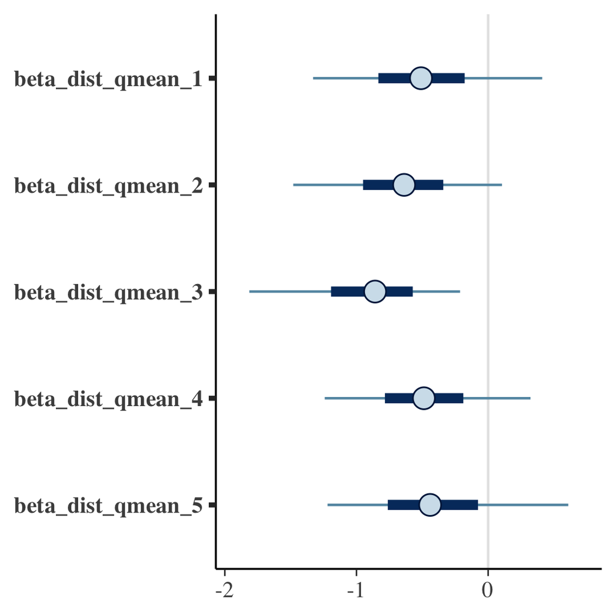

```r
## run changeBetaNames to make the parameter names understandable (so that we dont need to deal with matrix index)
dimnames(posterior)[[3]] = sampinfo::changeBetaNames(dimnames(posterior)[[3]],
                            beta = beta,
                            Q = max(format_data$qID),
                            S = max(format_data$sID))

bayesplot::mcmc_intervals(posterior, regex_pars = "^beta_dist_qmean")
```